# Homework 6

**Due: 2022-3-17, 10:30am (before the class)**

### Analysis Based on Score Dataset

We will use the **score dataset**, which we talked about as an example during the class. The data can be downloaded from [blackboard](https://blackboard.uthsc.edu/).

Suppose we are studying three different teaching methods for a course (independent variable). We also have student satisfaction scores and test scores (dependent variables). We want to determine whether the mean scores for satisfaction and tests differ between the three teaching methods.

You can use the commands `read.csv()` to read data in R.

```
##   Method  Test Satisfaction
## 1      1 3.000        3.001
## 2      1 2.990        2.994
## 3      1 3.041        3.032
## 4      1 3.063        3.059
## 5      1 3.035        3.026
## 6      1 3.009        3.003
```

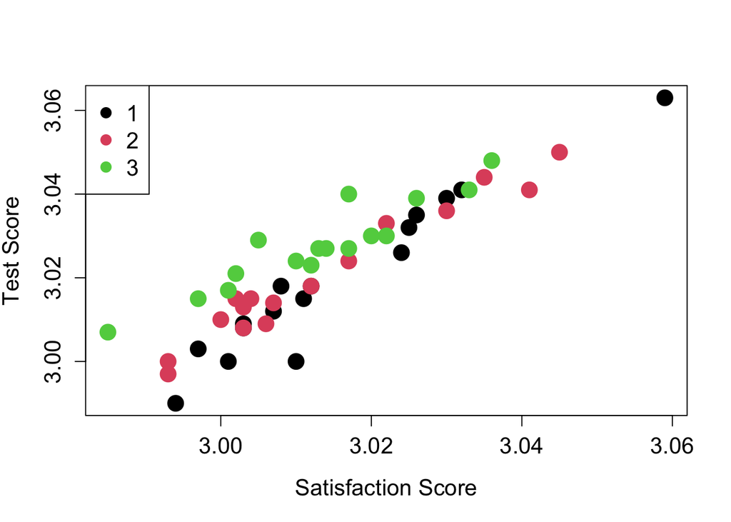

```r
# Scatter plot
plot(
  x = dat$Satisfaction,
  y = dat$Test,
  pch = 19,
  col = factor(dat$Method),
  xlab = "Satisfaction Score",
  ylab = "Test Score",
  cex=2,
  cex.axis=1.3,
  cex.lab=1.3
)
# Legend
legend("topleft",
       legend = levels(factor(dat$Method)),
       pch = 19,
       col = factor(levels(factor(dat$Method))),
       cex = 1.3)
```

1. (10%) Please calculate the mean and standard deviation of `Satisfaction` and `Test` for each `Method`.

```r
aggregate(. ~ Method, data = dat, mean)
```

```
##   Method     Test Satisfaction
## 1      1 3.019312     3.015125
## 2      2 3.020437     3.013313
## 3      3 3.027813     3.013125
```

```r
aggregate(. ~ Method, data = dat, sd)
```

```
##   Method       Test Satisfaction
## 1      1 0.01897268   0.01666083
## 2      2 0.01589117   0.01660008
## 3      3 0.01054020   0.01326587
```

2. (10%) Please apply MANOVA to test whether the mean scores for satisfaction and test differ between the three teaching methods.

```r
fit <- manova(cbind(Test,Satisfaction)~Method, data=dat)
summary(fit)
```

```
##           Df  Pillai approx F num Df den Df   Pr(>F)
## Method     1 0.45766   18.987      2     45 1.05e-06 ***
## Residuals 46
## ---
## Signif. codes:  0 '***' 0.001 '**' 0.01 '*' 0.05 '.' 0.1 ' ' 1
```

3. (10%) Please apply one-way ANOVA to test the mean differences between teaching methods of satisfaction score and test score, separately.

```r
summary.aov(fit)
```

```
##  Response Test :
##             Df   Sum Sq    Mean Sq F value Pr(>F)
## Method       1 0.000578 0.00057800  2.4264 0.1262
## Residuals   46 0.010958 0.00023822
##
##  Response Satisfaction :
##             Df   Sum Sq    Mean Sq F value Pr(>F)
## Method       1 0.000032 0.00003200  0.1345 0.7155
## Residuals   46 0.010944 0.00023791
```

### Analysis Based on Plant Dataset

Please download the [plant dataset](https://reneshbedre.github.io/assets/posts/ancova/manova_data.csv) and read the data using `read.csv()`. Suppose we have a dataset of various plant varieties (`plant_var`) and their associated phenotypic measurements for plant heights (`height`) and canopy volume (`canopy_vol`). We want to see if plant heights and canopy volume are associated with different plant varieties using MANOVA.

4. (15%) Please calculate the mean and standard deviation of `height` and `canopy_vol` for each `plant_var`. Plot to visualize if plant heights and canopy volume are associated with different plant varieties using MANOVA.

```r
df=read.csv("https://reneshbedre.github.io/assets/posts/ancova/manova_data.csv")
aggregate(. ~ plant_var, data = df, mean)
```

```
##   plant_var height canopy_vol
## 1         A  18.90      0.784
## 2         B  16.54      0.608
## 3         C   3.05      0.272
## 4         D   9.35      0.474
```

```r
aggregate(. ~ plant_var, data = df, sd)
```

```
##   plant_var   height canopy_vol
## 1         A 2.923088 0.12130769
## 2         B 1.920185 0.09681598
## 3         C 1.039498 0.14327906
## 4         D 2.106735 0.09453982
```

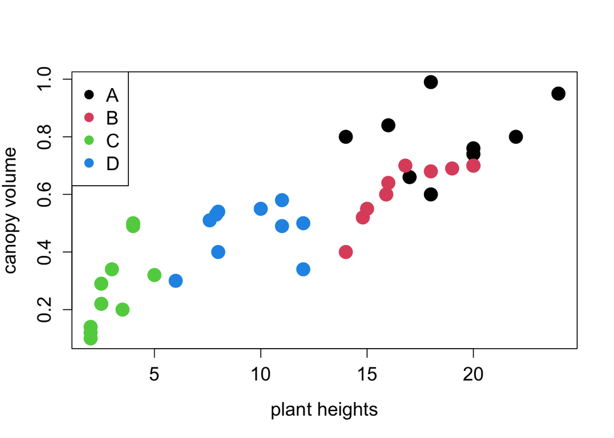

```r
plot(
  x = df$height,
  y = df$canopy_vol,
  pch = 19,
  col = factor(df$plant_var),
  xlab = "plant heights",
  ylab = "canopy volume",
  cex=2,
  cex.axis=1.3,
  cex.lab=1.3
)
# Legend
legend("topleft",
       legend = levels(factor(df$plant_var)),
       pch = 19,
       col = factor(levels(factor(df$plant_var))),
       cex = 1.3)
```

5. (20%) Please apply MANOVA to test whether the mean of plant heights and canopy volume differ between the four plant varieties. Please interpret the output.

```r
fit.plant <- manova(cbind(height, canopy_vol) ~ plant_var, data = df)
summary(fit.plant)
```

```
##           Df Pillai approx F num Df den Df    Pr(>F)
## plant_var  3 1.0365   12.909      6     72 7.575e-10 ***
## Residuals 36
## ---
## Signif. codes:  0 '***' 0.001 '**' 0.01 '*' 0.05 '.' 0.1 ' ' 1
```

The level means for the factor (plant varieties) are significantly different from each other across all responses (plant heights and canopy volume).

In other words, the factor (plant varieties) is at least associated with one response variable (plant heights, canopy volume, or both).

6. (20%) Please apply one-way ANOVA to test the mean differences between plant varieties of plant heights and canopy volume, separately. Please interpret the output.

```r
summary.aov(fit.plant)
```

```
##  Response height :
##             Df  Sum Sq Mean Sq F value    Pr(>F)
## plant_var    3 1553.40  517.80  116.68 < 2.2e-16 ***
## Residuals   36  159.75    4.44
## ---
## Signif. codes:  0 '***' 0.001 '**' 0.01 '*' 0.05 '.' 0.1 ' ' 1
##
##  Response canopy_vol :
##             Df Sum Sq Mean Sq F value   Pr(>F)
## plant_var    3 1.4022 0.46740  34.909 9.36e-11 ***
## Residuals   36 0.4820 0.01339
## ---
## Signif. codes:  0 '***' 0.001 '**' 0.01 '*' 0.05 '.' 0.1 ' ' 1
```

There is a statistically significant difference between plant varieties means for both plant heights and canopy volume.

7. (15%) Use the `TukeyHSD()` function to obtain all pairwise differences between plant varieties of plant heights.

```r
fit.height=aov(height~as.factor(plant_var),data=df)
TukeyHSD(fit.height)
```

```
##   Tukey multiple comparisons of means
##     95% family-wise confidence level
##
## Fit: aov(formula = height ~ as.factor(plant_var), data = df)
##
## $`as.factor(plant_var)`
##       diff        lwr         upr     p adj
## B-A  -2.36  -4.897246   0.1772462 0.0760884
## C-A -15.85 -18.387246 -13.3127538 0.0000000
## D-A  -9.55 -12.087246  -7.0127538 0.0000000
## C-B -13.49 -16.027246 -10.9527538 0.0000000
## D-B  -7.19  -9.727246  -4.6527538 0.0000000
## D-C   6.30   3.762754   8.8372462 0.0000005
```